# Homework 5

Victor Zhang

2023-03-11

## Exercise 1

```r
library(ggplot2)
library(kableExtra)
library(tidymodels)
library(tidyverse)
library(glmnet)
library(modeldata)
library(ggthemes)
library(janitor)
library(naniar)
library(corrplot)
library(themis)
tidymodels_prefer()
library(xgboost)
library(ranger)
library(vip)
```

```r
pokemon <- read.csv('/Users/victo/Desktop/data/Pokemon.csv')

pokemon <- pokemon %>%
  clean_names()
head(pokemon)
```

```
##   x                  name type_1 type_2 total hp attack defense sp_atk sp_def
## 1 1             Bulbasaur  Grass Poison   318 45     49      49     65     65
## 2 2               Ivysaur  Grass Poison   405 60     62      63     80     80
## 3 3              Venusaur  Grass Poison   525 80     82      83    100    100
## 4 3 VenusaurMega Venusaur  Grass Poison   625 80    100     123    122    120
## 5 4            Charmander   Fire          309 39     52      43     60     50
## 6 5            Charmeleon   Fire          405 58     64      58     80     65
##   speed generation legendary
## 1    45          1     False
## 2    60          1     False
## 3    80          1     False
## 4    80          1     False
## 5    65          1     False
## 6    80          1     False
```

All columns turn into snake case (all words start with lowercase letters and are separated by underscores, which makes them look_like_little_snakes). When we download data, the column names (variable names) may not all be in the same case or in a case that aren’t easy to work with. It can be helpful to change all column names so that they follow one universal naming convention.

## Exercise 2

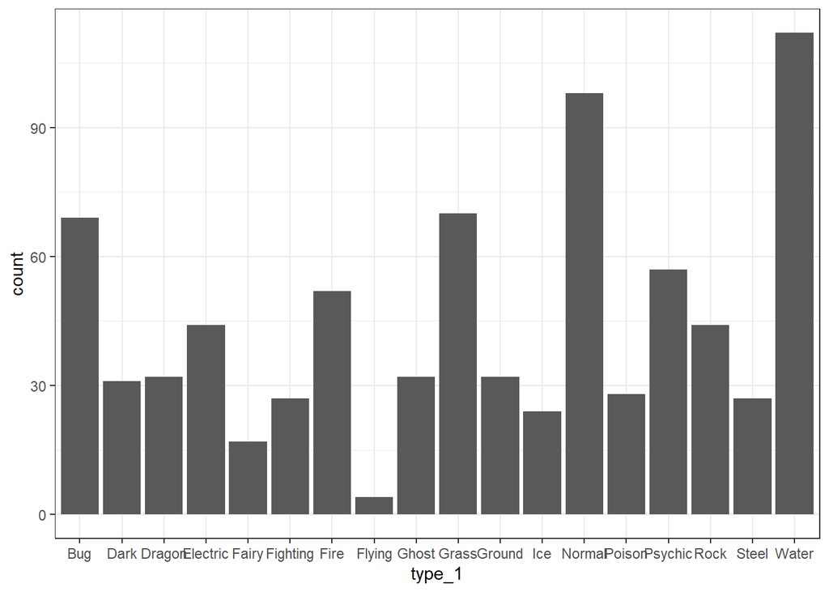

```r
pokemon %>%
  ggplot(aes(x = type_1)) + geom_bar() +
  theme_bw()
```

There are 18 classes of the outcome. Some classes like flying, fairy, and ice have only few pokemon, especially the flying class.

```r
pokemon$type_1 <- as.factor(pokemon$type_1)
pokemon$legendary  <- as.factor(pokemon$legendary )
pokemon$generation  <- as.factor(pokemon$generation )

pokemon2 <- pokemon
pokemon2$type_1 <- fct_lump_n(
  pokemon$type_1,
  6,
  w = NULL,
  other_level = "Other",
  ties.method = c("min", "average", "first", "last", "random", "max")
)
```

## Exercise 3

```r
set.seed(2333)

abalone_split <- initial_split(pokemon2, prop = 0.80, strata = type_1)

pokemon2_train <- training(abalone_split)
pokemon2_test <- testing(abalone_split)

dim(pokemon2_test)
```

```
## [1] 161  13
```

```r
dim(pokemon2_train)
```

```
## [1] 639  13
```

```r
pokemon2_folds <- vfold_cv(pokemon2_train, v = 5, strata = type_1)
```

Because it ensures the training and test sets have the same proportion of the feature of interest as in the original dataset.

## Exercise 4

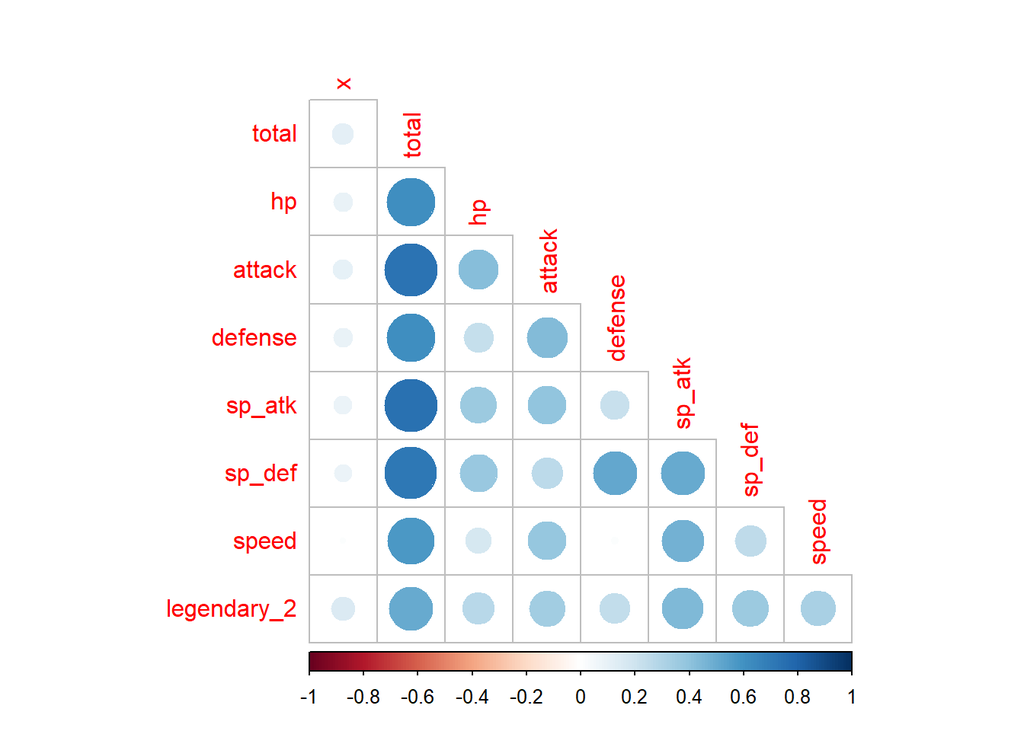

```r
pokemon2 <- pokemon2 %>%
  mutate(legendary_2 = case_when(legendary == "False" ~ "0",
                                legendary == "True" ~ "1"))


pokemon2$legendary_2 <- as.numeric(pokemon2$legendary_2)

pokemon2 %>%
  select(is.numeric) %>%
  cor() %>%
  corrplot(type = "lower", diag = FALSE)
```

For the categorical variable legendary that indicates whether a pokemon is a legendary pokemon or not, I mutate a new column legendary_2 that has value 1 if legendary has value Ture, and value 0 if legendary has value False. Thus, I can include the legendary status in the correlation matrix.

## Exercise 5

```r
pokemon2_recipe <- recipe(type_1  ~ legendary + generation + sp_atk + attack + speed + defense + hp + sp_def, data = pokemon2_train) %>%
  step_dummy(legendary, generation) %>%
  step_center(all_predictors()) %>%
  step_scale(all_predictors())
```

## Exercise 6

```r
multinom_reg_mod <- multinom_reg(mixture = tune(),
                              penalty = tune()) %>%
  set_mode("classification") %>%
  set_engine("glmnet")

multinom_reg_grid <- grid_regular(penalty(range = c(0.01, 3),
                                          trans = identity_trans()),
                                  mixture(range = c(0, 1)),
                                  levels = 10)


multinom_reg_workflow <- workflow() %>%
  add_recipe(pokemon2_recipe) %>%
  add_model(multinom_reg_mod)
```

## Exercise 7

```r
rf_mod <- rand_forest(mtry = tune(),
                           trees = tune(),
                           min_n = tune()) %>%
  set_engine("ranger", importance = "impurity") %>%
  set_mode("classification")

rf_wf <- workflow() %>%
  add_recipe(pokemon2_recipe) %>%
  add_model(rf_mod)

rf_grid <- grid_regular(mtry(range = c(1, 8)),
                        trees(range = c(1, 8)),
                        min_n(range = c(1, 8)),
                        levels = 8)
```

mtry is an integer for the number of predictors that will be randomly sampled at each split when creating the tree models. Since we have 8 predictors in total and 1 response variable, mtry is bounded by the total number of predictors, which is 8, and the minimum number of predictors that the regression process needs to produce a meaningful result, which is 1.

## Exercise 8

multinom_reg_mod_res <- tune_grid( multinom_reg_workflow, resamples = pokemon2_folds, grid = multinom_reg_grid )

rf_res <- tune_grid( rf_wf, resamples = pokemon2_folds, grid = rf_grid )

save(multinom_reg_mod_res, file = “multinom_reg_mod_res.rda”) save(rf_res, file = “rf_res.rda”)

```r
load("C:/Users/victo/Documents/PSTAT-131/rf_res.rda")
load("C:/Users/victo/Documents/PSTAT-131/multinom_reg_mod_res.rda")
```

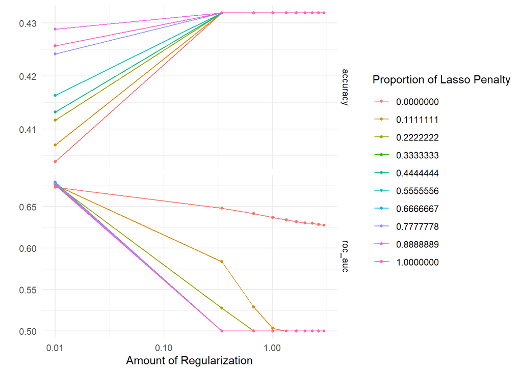

```r
autoplot(multinom_reg_mod_res) + theme_minimal()
```

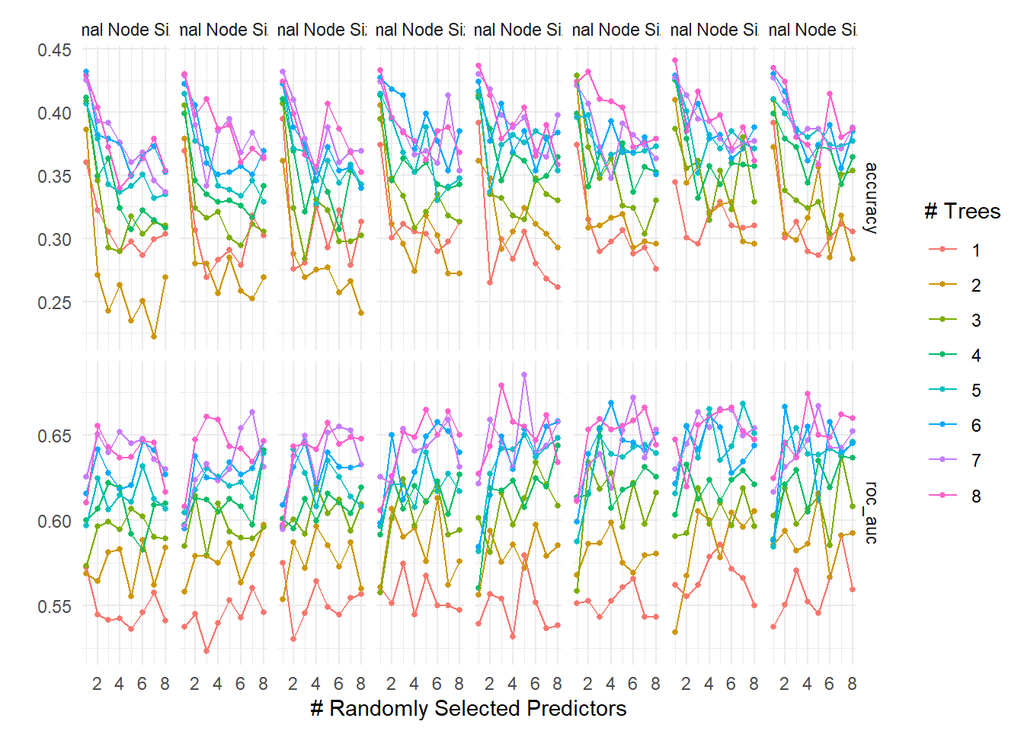

```r
autoplot(rf_res) + theme_minimal()
```

```r
show_best(multinom_reg_mod_res, n = 1)
```

```
## # A tibble: 1 × 8
##   penalty mixture .metric .estimator  mean     n std_err .config
##     <dbl>   <dbl> <chr>   <chr>      <dbl> <int>   <dbl> <chr>
## 1    0.01   0.667 roc_auc hand_till  0.679     5  0.0180 Preprocessor1_Model061
```

```r
best_multinom_reg<- select_best(multinom_reg_mod_res)
```

```r
show_best(rf_res, n = 1)
```

```
## # A tibble: 1 × 9
##    mtry trees min_n .metric .estimator  mean     n std_err .config
##   <int> <int> <int> <chr>   <chr>      <dbl> <int>   <dbl> <chr>
## 1     5     7     5 roc_auc hand_till  0.685     5  0.0100 Preprocessor1_Model3…
```

```r
best_rf <- select_best(rf_res)
```

The smaller values of penalty and mixture produce better ROC AUC. The best one is the one that has penalty 0.01 and mixture 0.6666667.

## Exercise 9

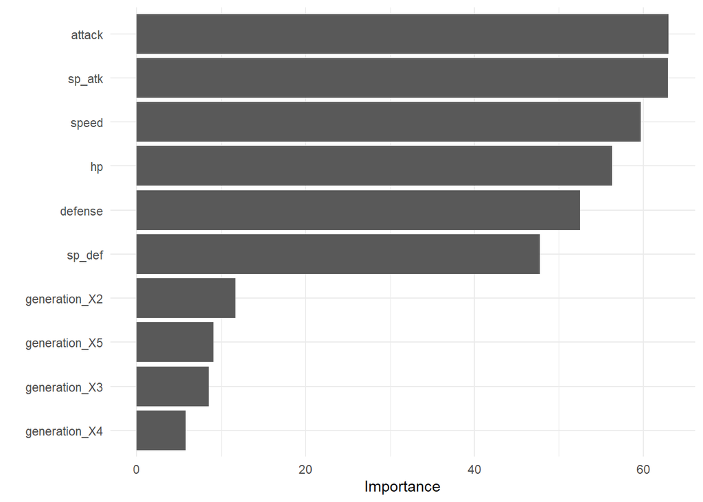

```r
final_rf_model <- finalize_workflow(rf_wf, best_rf)
final_rf_model <- fit(final_rf_model, pokemon2_train)

final_rf_model %>% extract_fit_parsnip() %>%
  vip() +
  theme_minimal()
```

```r
final_rf_model_test <- augment(final_rf_model,
                               pokemon2_test) %>%
  select(type_1, starts_with(".pred"))

roc_auc(final_rf_model_test, truth = type_1, .pred_Bug:.pred_Other
)
```

```
## # A tibble: 1 × 3
##   .metric .estimator .estimate
##   <chr>   <chr>          <dbl>
## 1 roc_auc hand_till      0.652
```

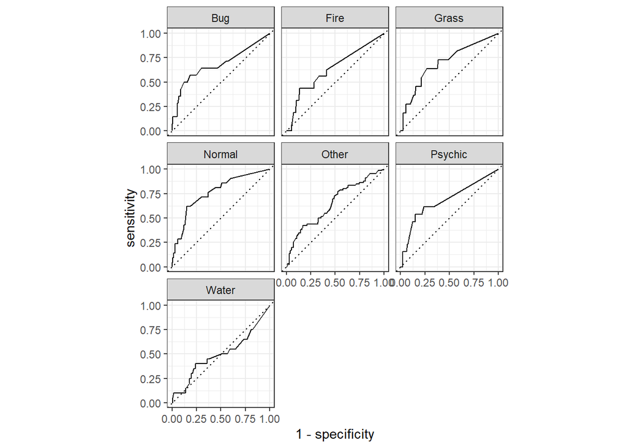

```r
roc_curve(final_rf_model_test, truth = type_1, .pred_Bug:.pred_Other) %>%
  autoplot()
```

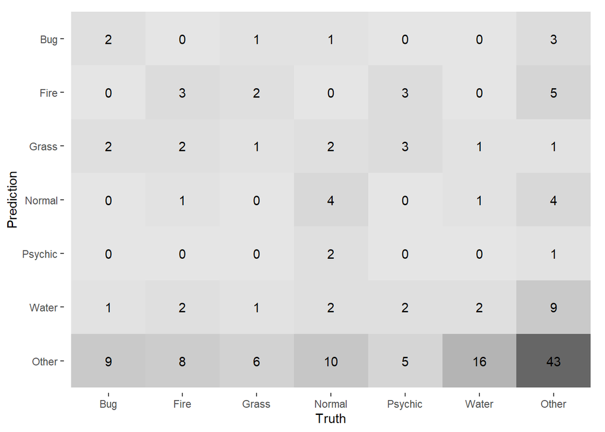

```r
conf_mat(final_rf_model_test, truth = type_1,
         .pred_class) %>%
  autoplot(type = "heatmap")
```

## Exercise 10

The model is best at predicting the other types of pokemon, and is worst at predicting the water types of pokemon.

One reason might be that the testing dataset has too few observation.